# Calculation of treatment-seeking rate

Back to DHS data

## Overview

Case management remains the primary intervention for reducing malaria-related morbidity and mortality in most endemic countries. Understanding care-seeking behavior and assessing the quality of care are critical for identifying districts where improvements are needed. In the context of the SNT, two key indicators—care-seeking behavior and quality of care—are derived using data from community surveys (such as DHS/MIS) and routine health information systems (DHIS2). The following steps focus on estimating the care-seeking rate, which is crucial in epidemiological stratification. Specifically, it calculates the incidence adjusted for testing, reporting, and care-seeking behavior (“Adjustment 3”) within the WHO framework.

Three indicators of care-seeking behavior for febrile children under five are estimated:

- Proportion who sought care in the public sector
- Proportion who sought care in the private sector
- Proportion who did not seek any care

**Objectives**

- Install, load, and define functions
- Import, select and compute the new variables
- Estimating each indicator using the R surveys package at the regional level
- Renaming the region labels
- Visualizing indicators by year
- Save output as CSV for fusion

## Key Information to take into account in the context of SNT

When estimating the treatment-seeking rate for SNT, we should consider the following points:

**Which administrative level does the estimate use?**

> We’ll use DHS/MIS data at the regional level. Typically, these surveys are representative at the national and regional (administrative level 1) levels. In this case, all districts within the same region will receive the same estimate. However, we can generate district-level estimates for greater precision by applying a Bayesian geospatial model such as integrated nested Laplace approximation(INLA). However, the INLA model syntax is highly technical and often confuses beginners, who need a solid understanding of Bayesian and spatial modeling to use it effectively. In addition, the method relies on complex mathematical concepts such as Bayesian inference, SPDEs, and GMRFs. In this chapter, we’ll focus on producing estimates at the regional level.

**How should we handle years without survey data?**

> DHS surveys are generally conducted every 5 years, although the frequency may change based on a country’s needs and available funding. MIS surveys are often conducted more frequently—every 2 to 3 years—in countries with a high disease burden or where frequent updates are needed to monitor malaria control progress. Because surveys are not conducted every year, NMCPs must choose how to address data gaps in non-survey years. Their options include:
- Interpolating data linearly between survey years
- Applying data from one survey year to subsequent years until a new survey is conducted
- Using data from the most recent survey for the entire period without updates.

In this chapter, we focus on the estimates based on the available surveys and do not use linear interpolation.

## Step-by-Step

This section covers the estimation of the treatment-seeking rate by source. It will guide you through importing the data, selecting and computing new variables for treatment sources, estimating the treatment-seeking rate while accounting for the survey sampling plan, and finally, visualizing and saving the results for future use. This chapter works with data that includes the children < 5 of the interviewed women’s files (KR). For more information about the file types in DHS/MIS [click here](https://dhsprogram.com/data/Dataset-Types.cfm).

### Step 1: Install, load libraries, and define functions

To estimate the treatment-seeking rate, we’ll use the DHS/MIS data from AHADI’s [snt-data-files GitHub repository](https://github.com/ahadi-analytics/snt-data-files). First, we will install and load the necessary packages for this section. Then, we will load all the functions needed for the analysis.

#### Step 1.1: Install and load libraries

As shown in the data preprocessing chapter, you must install any missing packages and load them. The code chunck below showns the loading of packages required for the analyses.

**R**

```r
# Install pacman only if it's not already installed
if (!requireNamespace("pacman", quietly = TRUE)) {
  install.packages("pacman")
}

# install or load relevant packages
pacman::p_load(
  tidyverse, # core tidy tools (includes dplyr, tidyr, readr, etc.)
  haven,     # read and write various data formats (stata)
  httr,      # download files from web (GET, write_disk)
  rio,       # importing data
  here,      # relative file pathways
  data.table,# is an excellent extension of the data.frame class
  fs,        # handle file paths
  purrr,     # iterate over lists (map, walk, etc.)
  rlang,     # for tidy evaluation and error messaging
  survey,    # analyzing data from complex surveys
  sf,        # Support for simple feature access, a standardized way
             # to encode and analyze spatial vector data
  tmap       # drawing thematic maps

)
```

**Python**

#### Step 1.2: Define functions

We start by defining helper functions that import data, create a complex survey design object, compute survey-weighted proportions, and estimate proportions.

**R**

```r
#' Reads and combines multiple dta files from a directory into a single
#' list.
#'
#' This function searches for files with the specified extension in the given
#' directory and combines them into a single list.
#'
#' @param directory Path to directory containing files
#'    (default: "english/data_r")
#' @param pattern File extension (default: "dta").
#'   "dta" format available in haven package.
#' @return A list combining all files with trimmed column names. Returns
#'    NULL if no files found or if an error occurs during reading/combining.
#' @examples
#' # Read DTA files
#' dhs <- read_dta("path/to/data", ".dta")

  # directory <- here::here(directory)
  data_dir <- "~/snt-code-library/english/data_r/"


 # Read all the files in the list
 read.files <- function(filepat, path, fun, encoding = "latin1") {
   # Find files matching the pattern
  filenames <- list.files(path = path, pattern = filepat, recursive = TRUE, full.names = TRUE)
  # Combine all list
  sapply(filenames, fun, simplify = F)

 }


 # Create a complex survey design object
 svydesign.fun <- function(filename){
  # create a survey design object
  survey::svydesign(id= ~id,
            strata=~strate,nest=T,
            weights= ~wt, data=filename)
}


#Computes survey-weighted proportions
 result.prop<- function(var, var1, design) {
  p_est<-survey::svyby(formula=make.formula(var), by=make.formula(var1), FUN=svymean, design, levels=0.95, vartype= "ci", na.rm=T, influence = TRUE)
}

 #estimation functions
estim_prop <- function(df, col, by){
  svy_mal <- svydesign.fun(df)
  region_est <- result.prop(col, by, design=svy_mal)
}
```

**Python**

To properly adapt `read.files()` the code in your script, be sure to update the following:

- Change the file path: `directory = "/path to directory/"`
- Use the right pattern: `".*KR.*\\.DTA"`

### Step 2: Import, select and compute the new variables

In this section, we select and compute new variables. We calculated the percentage of children who had a fever in the two weeks prior to the survey and sought advice or treatment from different sources. Another alternative is to calculate the percentage of children who had a fever in the two weeks before the survey, who tested positive for a rapid diagnostic test, and sought advice or treatment from different sources. The next chapter will discuss this option. Clarify with the PNLP which options best fit their local context.

For more information on variable names, grouping, and filter criteria [click here](https://dhsprogram.com/publications/publication-DHSG4-DHS-Questionnaires-and-Manuals.cfm).

**R**

```r
 # Read all the files in the list

dhs_SL <- read.files(".*KR.*\\.DTA", data_dir, read_dta)

# Read the files in the list (2016 and 2019)
dhs <- dhs_SL |>
  # Select the variables to include for all the lists
  purrr::map(~dplyr::select(., caseid, v001, v002, v003, v007, v012, v022, v021, v024 ,v101,
                      v005, b5, b8, b19, h22, h32a:h32y)) |>
  # Rename region using the variables v024 and v101
  purrr::map(~dplyr::mutate(., region = ifelse(is.na(v024), v101, v024),
                     wt=v005/1000000, strate = v022,id = v021)) |>
  # Filter by key factors (child alive: b5, child current age:b19 and child had a fever in last two weeks: h22)
  purrr::map(~dplyr::filter(., b5 == 1 & b19 < 60 & h22 == 1))|>
  # Sum by row for each source (prop_publ=public, prop_priv=private and no_trea=no seeking treatment)
  purrr::map(~dplyr::mutate(., prop_publ = rowSums(dplyr::select(., h32a, h32b, h32c, h32d, h32e, h32f, h32g, h32h, h32i), na.rm = TRUE),
              prop_priv = rowSums(dplyr::select(., h32j, h32k, h32l, h32m, h32n, h32o, h32p, h32q, h32r, h32s, h32t, h32u, h32v, h32w, h32x), na.rm = TRUE),
              prop_publ = ifelse(prop_publ > 0, 1, 0),
              prop_priv = ifelse(prop_priv > 0, 1, 0),
              prop_publ = ifelse(prop_publ == 1 & prop_priv ==1, 1, prop_publ),
              no_trea = ifelse(h32y == 0, 0, 1)

  ))
```

### Step 3: Estimating each indicator using the R surveys package at the regional level

In this section, we estimate the care-seeking rate by source. The program below loops through a list of DHS datasets, calculates proportions for three care-seeking indicators (public, private, no treatment) by region and year, rounds and formats the results, and compiles them into a single data frame.

**R**

```r
# Initialize an empty data frame for results
data_care_seeking <- dplyr::tibble()

# Define indicators
vars <- c("prop_publ", "prop_priv", "no_trea")

# Handle single PSU strata
options(survey.lonely.psu = "adjust")

# Process each dataset in dhs file
data_care_seeking <- purrr::map_dfr(dhs, ~ {
  # Add a year column
  df <- .x |> dplyr::mutate(year = v007)

  # Compute proportions for each indicator
  care_data <- purrr::map(vars, ~ {
    estim_prop(df, col = .x, by = c("region", "year"))
  })

  # Combine results, rename columns, and format
  dplyr::bind_cols(care_data[[1]], care_data[[2]], care_data[[3]]) |>
    dplyr::rename(region = 1, year = 2) |>
    dplyr::select(region, year, prop_publ, prop_priv, no_trea) |>
    dplyr::mutate(
      prop_publ = round(prop_publ, 2),
      prop_priv = round(prop_priv, 2),
      no_trea = round(no_trea, 2),
      region = as.numeric(region),
      year = as.numeric(year)
    )
})

head(data_care_seeking,4)
```

```
       region year prop_publ prop_priv no_trea
1.2016      1 2016      0.69      0.07    0.25
2.2016      2 2016      0.64      0.08    0.28
3.2016      3 2016      0.68      0.10    0.23
4.2016      4 2016      0.41      0.19    0.42
```

**Important points**

- The PNLP may decide to reduce the proportion of care-seeking in the private sector by `x%` due to local context. In this case, add the following line just below **line 26**: `prop_priv2 <- prop_priv/x%`.

### Step 4: Renaming the region labels

We transform the `data_care_seeking` dataframe by adding an adm1 column that maps numeric region values and specific year conditions to descriptive region names, and then we remove the original region column. This enables merging with the shapefile and other cleaned datasets.

Install the `install.packages("labelled")` package and use the `look_for(dhs_SL[[1]], "region")` function to find the region names in the first element of your list.

**R**

```r
### # Transform the data_care_seeking data frame by adding a new 'adm1' column and removing the 'region' column
data_care_seeking <- data_care_seeking |>
  dplyr::mutate(
    adm1 = dplyr::case_when(
      region == 1  ~ "eastern",
      region == 2  ~ "northern",
      year==2019 & region == 3  ~ "north western",
      year==2016 & region == 3  ~ "southern",
      year== 2019 & region == 4  ~ "southern",
      year== 2016 & region == 4  ~ "western",
      region == 5  ~ "western",
      TRUE         ~ ""
    )
  ) |>

  # D# Remove the 'region' column from the data frame
  dplyr::select(-region)


head(data_care_seeking,4)
```

```
       year prop_publ prop_priv no_trea     adm1
1.2016 2016      0.69      0.07    0.25  eastern
2.2016 2016      0.64      0.08    0.28 northern
3.2016 2016      0.68      0.10    0.23 southern
4.2016 2016      0.41      0.19    0.42  western
```

### Step 5: Visualizing indicators by year

To visualize these three indicators at the regional level, we first need to import the region shapefile. We will follow the same procedure to import and clean shapefiles as we used in Step 5 of the Population-Country-Sourced Population Data chapter [click here](https://ahadi-analytics.github.io/snt-code-library/english/library/data/routine_cases/import.html).

We will use the `tmap` for visualization. However, we can also visualize using `ggplot`, as shown in other sections.

**R**

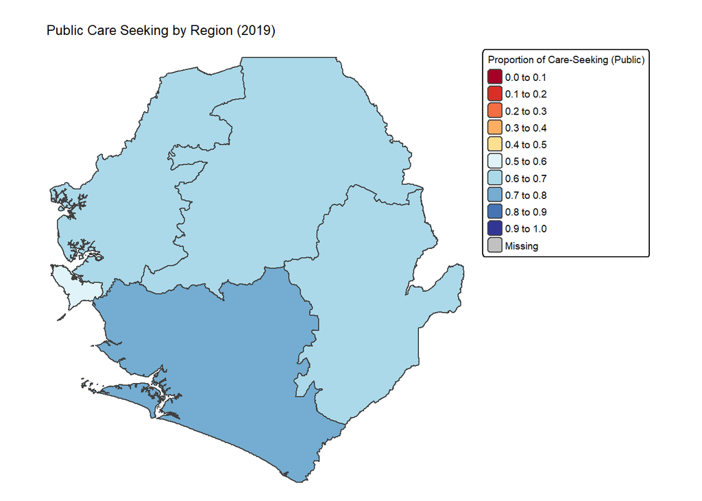

```r
dir_shp <- "~/snt-code-library/english/data_r"

### Import the shapefile using st_read

shp=sf::st_read(file.path(dir_shp,'sle_admbnda_adm1_gov_ocha_20231215.shp'), quiet = TRUE) |>
   dplyr::mutate(adm1=tolower(ADM1_EN))

# Merge shapefile with care-seeking date and keep only 2019

shp_region= shp |>
  dplyr::left_join(data_care_seeking, by=c("adm1"),
            relationship = "many-to-many") |>
 dplyr::filter(year==2019)


  # Create tmap for prop_publ
shp_region |>
  tmap::tm_shape() +
  tmap::tm_polygons(
    "prop_publ",
    title = "Proportion of Care-Seeking (Public)",
    breaks = c(0, 0.1, 0.2, 0.3, 0.4, 0.5, 0.6, 0.7, 0.8, 0.9, 1),
    palette = "RdYlBu"
  ) +
    tmap::tm_facets(
    by = "year",
    nrow = 1,
    free.scales = FALSE
  ) +
  tmap::tm_layout(
    legend.outside = TRUE,
    legend.title.size = 0.6,
    legend.text.size = 0.6,
    frame = FALSE,
    main.title = "Public Care Seeking by Region (2019)",
    main.title.size = 0.8
  )
```

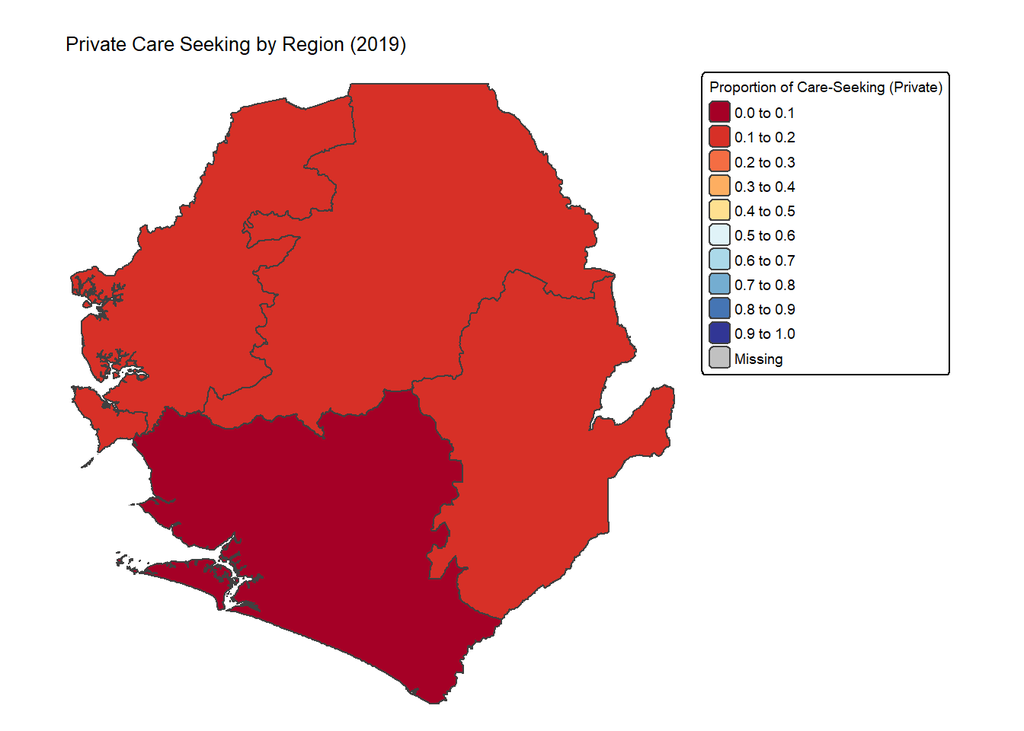

```r
# Create tmap for prop_priv
tmap::tm_shape(shp_region) +
  tmap::tm_polygons(
    "prop_priv",
    title = "Proportion of Care-Seeking (Private)",
    breaks = c(0, 0.1, 0.2, 0.3, 0.4, 0.5, 0.6, 0.7, 0.8, 0.9, 1),
    palette = "RdYlBu"
  ) +
    tmap::tm_facets(
    by = "year",
    nrow = 1,
    free.scales = FALSE
  ) +
  tmap::tm_layout(
    legend.outside = TRUE,
    legend.title.size = 0.6,
    legend.text.size = 0.6,
    frame = FALSE,
    main.title = "Private Care Seeking by Region (2019)",
    main.title.size = 0.8
  )
```

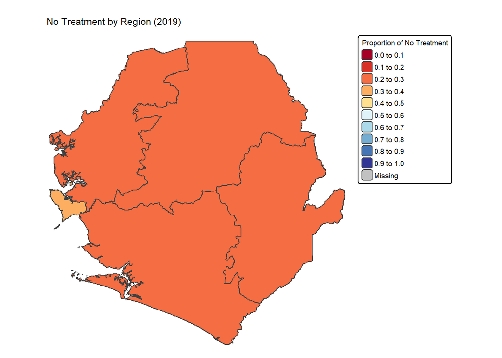

```r
# Create tmap for no_trea with one legend
tmap::tm_shape(shp_region) +
  tmap::tm_polygons(
    col = "no_trea",
    title = "Proportion of No Treatment",
    breaks = c(0, 0.1, 0.2, 0.3, 0.4, 0.5, 0.6, 0.7, 0.8, 0.9, 1),
    palette = "RdYlBu",
    legend.show = TRUE
  ) +
  tmap::tm_facets(
    by = "year",
    nrow = 1,
    free.scales = FALSE
  ) +
  tmap::tm_layout(
    legend.outside = TRUE,
    legend.title.size = 0.6,
    legend.text.size = 0.6,
    frame = FALSE,
    main.title = "No Treatment by Region (2019)",
    main.title.size = 0.8
  )
```

**Creating a Thematic Map with tmap: Example for prop_publ**

This code creates a thematic map (tmap) visualizing the proportion of public care-seeking (prop_publ) across regions, with the following steps:

- It uses the `tm_shape()` function to define the spatial data (shp_region).
- The `tm_polygons()` function visualizes the `prop_publ` variable, setting color breaks, a title, and a color `palette ("RdYlBu")`.
- The `tm_facets()` function generates multiple panels for each year, arranged in one row with consistent axes. You don’t need to do this if you only have one year.
- The `tm_layout()` function customizes the map’s appearance, including positioning the legend outside, adjusting legend sizes, removing the frame, and adding a `main title ("Public Care Seeking by Region (2019)")`.

### Step 6: Save the output

Now that we have estimated the three indicators at regional level, we will save the file in the appropriate format for use in epidemiological stratification.

Make sure you check your `save_path` for the location of your output CSV file.

**R**

```r
 #set up output path
#set up output path
save_path <- here::here("english", "data_r")


# Verify directory exists, create if it doesn't
if (!dir.exists(save_path)) {
  dir.create(save_path, recursive = TRUE)
}


# save to csv
rio::export(data_care_seeking, here::here(save_path, "care_seeking_data.csv"))
```

## Summary

We have now demonstrated how to import data, select variables, apply filter conditions, and create new variables. We have also shown how to use the R surveys package to calculate the proportion of care-seeking at the regional level, considering the survey sample design. Everything is now cleaned, structured, and ready to merge with the routine data for epi-stratification in the SNT pipeline. The full code, reduced for ease of reference, is provided at the bottom of this section. You can reuse it as is or modify it for your configuration by updating the file paths and survey type.

### Full code

**R**

**Full code**

```r
# Step 1
# Step 1.2
# Install pacman only if it's not already installed
if (!requireNamespace("pacman", quietly = TRUE)) {
  install.packages("pacman")
}

# install or load relevant packages
pacman::p_load(
  tidyverse, # core tidy tools (includes dplyr, tidyr, readr, etc.)
  haven,     # read and write various data formats (stata)
  httr,      # download files from web (GET, write_disk)
  data.table,# is an excellent extension of the data.frame class
  fs,        # handle file paths
  purrr,     # iterate over lists (map, walk, etc.)
  rlang,     # for tidy evaluation and error messaging
  survey,     # analyzing data from complex surveys
  plyr,      # tool for splitting, applying, and combining data
  sf,       #
  tmap      #

)


# Step 1.2

#' Reads and combines multiple dta files from a directory into a single
#' list.
#'
#' This function searches for files with specified extension in the given
#' directory and combines them into a single list.
#'
#' @param directory Path to directory containing files
#'    (default: "english/data_r/DHS")
#' @param pattern File extension (default: "dta").
#'   "dta" format available in haven package.
#' @return A list combining all files with trimmed column names. Returns
#'    NULL if no files found or if an error occurs during reading/combining.
#' @examples
#' # Read DTA files
#' dhs <- read_dta("path/to/data", ".dta")

# directory <- here::here(directory)
data_dir <- "~/snt-code-library/english/data_r/"


# Read all the files in the list
read.files <- function(filepat, path, fun, encoding = "latin1") {
  # Find files matching the pattern
  filenames <- list.files(path = path, pattern = filepat, recursive = TRUE, full.names = TRUE)
  # Combine all list
  sapply(filenames, fun, simplify = F)

}


# Create a complex survey design object
svydesign.fun <- function(filename){
  # create a survey design object
  survey::svydesign(id= ~id,
            strata=~strate,nest=T,
            weights= ~wt, data=filename)
}


#Computes survey-weighted proportions
result.prop<- function(var, var1, design) {
  p_est<-survey::svyby(formula=make.formula(var), by=make.formula(var1), FUN=svymean, design, levels=0.95, vartype= "ci", na.rm=T, influence = TRUE)
}

#estimation functions
estim_prop <- function(df, col, by){
  svy_mal <- svydesign.fun(df)
  region_est <- result.prop(col, by, design=svy_mal)
}




# Step 2

# Import all the files in the list

dhs_SL <- read.files(".*KR.*\\.DTA", data_dir, read_dta)
# Read the files in the list
dhs<- dhs_SL |>
  # Select the variables to include for all the lists
  purrr::map(~dplyr::select(., caseid, v001, v002, v003, v007, v012, v022, v021, v024 ,v101,
                            v005, b5, b8, b19, h22, h32a:h32y)) |>
  # Rename region using the variables v024 and v101
  purrr::map(~dplyr::mutate(., region = ifelse(is.na(v024), v101, v024), wt=v005/1000000,
                            strate = v022,
                            id = v021)) |>
  # Filter by key factors (child alive: b5, child current age:b19 and child had a fever in last two weeks: h22)
  purrr::map(~dplyr::filter(., b5 == 1 & b19 < 60 & h22 == 1))|>
  # Sum by row for each source (prop_publ=public, prop_priv=private and no_trea=no seeking treatment)
  purrr::map(~dplyr::mutate(., prop_publ = rowSums(dplyr::select(., h32a, h32b, h32c, h32d, h32e, h32f, h32g, h32h, h32i), na.rm = TRUE),
                            prop_priv = rowSums(dplyr::select(., h32j, h32k, h32l, h32m, h32n, h32o, h32p, h32q, h32r, h32s, h32t, h32u, h32v, h32w, h32x), na.rm = TRUE),
                            prop_publ = ifelse(prop_publ > 0, 1, 0),
                            prop_priv = ifelse(prop_priv > 0, 1, 0),
                            prop_publ = ifelse(prop_publ == 1 & prop_priv ==1, 1, prop_publ),
                            no_trea = ifelse(h32y == 0, 0, 1)

  ))



# Step 3

# Initialize an empty data frame for results
data_care_seeking <- dplyr::tibble()

# Define indicators
vars <- c("prop_publ", "prop_priv", "no_trea")

# Handle single PSU strata
options(survey.lonely.psu = "adjust")

# Process each dataset in DHS
data_care_seeking <- purrr::map_dfr(dhs, ~ {
  # Add a year column
  df <- .x |> dplyr::mutate(year = v007)

  # Compute proportions for each indicator
  care_data <- purrr::map(vars, ~ {
    estim_prop(df, col = .x, by = c("region", "year"))
  })

  # Combine results, rename columns, and format
  dplyr::bind_cols(care_data[[1]], care_data[[2]], care_data[[3]]) |>
    dplyr::rename(region = 1, year = 2) |>
    dplyr::select(region, year, prop_publ, prop_priv, no_trea) |>
    dplyr::mutate(
      prop_publ = round(prop_publ, 2),
      prop_priv = round(prop_priv, 2),
      no_trea = round(no_trea, 2),
      region = as.numeric(region),
      year = as.numeric(year)
    )
})


# Step 4


data_care_seeking <- data_care_seeking |>
  dplyr::mutate(
    adm1 = dplyr::case_when(
      region == 1  ~ "eastern",
      region == 2  ~ "northern",
      year==2019 & region == 3  ~ "north western",
      year==2016 & region == 3  ~ "southern",
      year== 2019 & region == 4  ~ "southern",
      year== 2016 & region == 4  ~ "western",
      region == 5  ~ "western",
      TRUE         ~ ""
    )
  ) |>

  # D# Remove the 'region' column from the data frame
  dplyr::select(-region)


# Step 5

dir_shp <- "~/snt-code-library/english/data_r"

### Import the shapefile using st_read

shp=sf::st_read(file.path(dir_shp,'sle_admbnda_adm1_gov_ocha_20231215.shp'),quiet = TRUE) |>
  dplyr::mutate(adm1=tolower(ADM1_EN))

# Merge shapefile with care-seeking date

shp_region= shp |>
  dplyr::left_join(data_care_seeking, by=c("adm1"),
                   relationship = "many-to-many") |>
  dplyr::filter(year==2019)


# Create tmap for prop_publ
map_publ <- shp_region |>
  tmap::tm_shape() +
  tmap::tm_polygons(
    "prop_publ",
    title = "Proportion of Care-Seeking (Public)",
    breaks = c(0, 0.1, 0.2, 0.3, 0.4, 0.5, 0.6, 0.7, 0.8, 0.9, 1),
    palette = "RdYlBu"
  ) +
  tmap::tm_facets("year", nrow = 1) +
  tmap::tm_layout(
    legend.outside = TRUE,
    legend.title.size = 0.6,
    legend.text.size = 0.6,
    frame = FALSE,
    main.title = "Public Care Seeking by Region (2019)",
    main.title.size = 0.8
  )

# Create tmap for prop_priv
map_priv<- tmap::tm_shape(shp_region) +
  tmap::tm_polygons(
    "prop_priv",
    title = "Proportion of Care-Seeking (Private)",
    breaks = c(0, 0.1, 0.2, 0.3, 0.4, 0.5, 0.6, 0.7, 0.8, 0.9, 1),
    palette = "RdYlBu"
  ) +
  tmap::tm_facets("year", nrow = 1) +
  tmap::tm_layout(
    legend.outside = TRUE,
    legend.title.size = 0.6,
    legend.text.size = 0.6,
    frame = FALSE,
    main.title = "Private Care Seeking by Region (2019)",
    main.title.size = 0.8
  )

# Create tmap for no_trea with one legend
map_notr<- tmap::tm_shape(shp_region) +
  tmap::tm_polygons(
    col = "no_trea",
    title = "Proportion of No Treatment",
    breaks = c(0, 0.1, 0.2, 0.3, 0.4, 0.5, 0.6, 0.7, 0.8, 0.9, 1),
    palette = "RdYlBu",
    legend.show = TRUE
  ) +
  tmap::tm_facets(
    by = "year",
    nrow = 1,
    free.scales = FALSE  # Ensures the same scale (and legend) across facets
  ) +
  tmap::tm_layout(
    legend.outside = TRUE,
    legend.title.size = 0.6,
    legend.text.size = 0.6,
    frame = FALSE,
    main.title = "No Treatment by Region (2019)",
    main.title.size = 0.8
  )

# Step 6

#set up output path
save_path <- here::here("english", "data_r")


# Verify directory exists, create if it doesn't
if (!dir.exists(save_path)) {
  dir.create(save_path, recursive = TRUE)
}


# save to csv
rio::export(data_care_seeking, here::here(save_path, "care_seeking_data.csv"))

# Save plots
tmap::tmap_save(map_notr, file.path(save_path, "no_treatment.png"))

tmap::tmap_save(map_publ, file.path(save_path, "public_care_seeking.png"))

tmap::tmap_save(map_priv, file.path(save_path, "private_care_seeking.png"))
```